# 202140090-홍기현-Assignment2

## 202140090-홍기현-Assignment2

### 필요 모듈 import

```python
import numpy as np
import cv2
from matplotlib import pyplot as plt
import math
import os
import mtcnn
import numpy as np

from keras.preprocessing.image import ImageDataGenerator
from skimage.color import rgb2gray
from skimage.transform import resize
from scipy import signal
from scipy.fftpack import fft, fftshift
from random import random
from keras import models
from keras import layers

print(mtcnn.__version__)
```

```
0.1.0
```

#### Harr Cascades를 이용한 얼굴 검출

- 눈, 코, 입 검출 데이터 세트 수집을 위해 기존에 개발된 알고리즘을 이용한다.
- Harr Cascades는 머신러닝 기반의 오브젝트 검출 알고리즘
- Harr Cascades를 통하여 정면의 이미지에서 눈, 코, 입을 분류하는지 여부를 확인한다.

#### Harr Cascades를 이용한 얼굴 검출 알고리즘

- haarcascade_frontalface_alt.xml: 얼굴 검출
- haarcascade_eye.xml: 눈 검출
- 정면 이미지에서 얼굴을 먼저 검출한 후에 그 안에서 눈을 검출

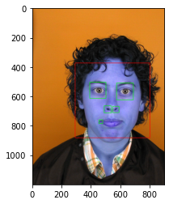

```python
face_cascade = cv2.CascadeClassifier('./wei/haarcascade_frontalface_alt.xml')
eye_cascade = cv2.CascadeClassifier('./wei/haarcascade_eye.xml')

img = cv2.imread('./faces/f4001.jpg')
gray = cv2.cvtColor(img, cv2.COLOR_BGR2GRAY)

faces = face_cascade.detectMultiScale(gray, 1.3, 5)

for (x,y,w,h) in faces:
    cv2.rectangle(img,(x,y),(x+w,y+h),(255,0,0),2)
    roi_gray = gray[y:y+h, x:x+w]
    roi_color = img[y:y+h, x:x+w]
    eyes = eye_cascade.detectMultiScale(roi_gray)
    for (ex,ey,ew,eh) in eyes:
        cv2.rectangle(roi_color,(ex,ey),(ex+ew,ey+eh),(0,255,0),2)

plt.imshow(img)
cv2.destroyAllWindows()
```

- 검출 결과를 보면 눈뿐만이 아니라 다른 부위도 포함된 것이 보인다.
- 이를 개선하여 눈만 검출되도록 한다.
- 정면의 사진에서 사람의 눈은 위의 2개이므로 위 2개를 제외한 특징은 검출하지 않도록 함

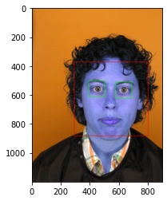

```python
face_cascade = cv2.CascadeClassifier('./wei/haarcascade_frontalface_alt.xml')
eye_cascade = cv2.CascadeClassifier('./wei/haarcascade_eye.xml')

img = cv2.imread('./faces/f4001.jpg')
gray = cv2.cvtColor(img, cv2.COLOR_BGR2GRAY)

faces = face_cascade.detectMultiScale(gray, 1.3, 5)

for (x,y,w,h) in faces:
    cv2.rectangle(img,(x,y),(x+w,y+h),(255,0,0),2)
    roi_gray = gray[y:y+h, x:x+w]
    roi_color = img[y:y+h, x:x+w]
    eyes = eye_cascade.detectMultiScale(roi_gray)
    for i, (ex,ey,ew,eh) in enumerate(eyes):
        if len(eyes) - i < 3:
            cv2.rectangle(roi_color,(ex,ey),(ex+ew,ey+eh),(0,255,0),2)

plt.imshow(img)
cv2.destroyAllWindows()
```

- 그러나, Harr Cascades 알고리즘의 한계점은 얼굴과 눈은 검출할 수 있지만, 코와 입은 검출할 수 없다.
- 따라서, Harr Cascades가 아닌 다른 방법을 통해 눈, 코, 입을 검출하도록한다.

#### MTCNN

- MTCNN은 Tensorflow에 기반한 얼굴 감지를 위한 CNN 알고리즘
- Harr Cascades와 마찬가지로 정면의 이미지에서 얼굴과 눈, 코, 입을 검출
- NTCNN을 위해 데이터 확인 및 전처리를 수행
- 데이터 셋의 첫번째 이미지는 f4001.jpg이며 다음과 같다.

```
Shape of image/array: (1200, 900, 3)
```

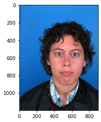

```python
filename = './faces/f4001.jpg'
pixels = plt.imread(filename)
print("Shape of image/array:",pixels.shape)
imgplot = plt.imshow(pixels)
plt.show()
```

- MTCNN을 통해 정면 이미지에서 얼굴과 눈, 코, 입을 식별한 결과는 다음과 같다.
- 얼굴은 주황색 사각형으로, 눈, 코, 입은 빨간 점으로 표현하였다.

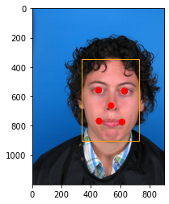

```python
filename = './faces/f4001.jpg'
pixels = plt.imread(filename)

detector = mtcnn.MTCNN()

faces = detector.detect_faces(pixels)

def draw_facebox(filename, result_list):
    data = plt.imread(filename)
    plt.imshow(data)
    ax = plt.gca()

    for result in result_list:
        x, y, width, height = result['box']
        rect = plt.Rectangle((x, y), width, height,fill=False, color='orange')
        ax.add_patch(rect)

        for key, value in result['keypoints'].items():
            dot = plt.Circle(value, radius=20, color='red')
            ax.add_patch(dot)

        # plt.show()
        plt.savefig('savefig_default.png')

faces = detector.detect_faces(pixels)

draw_facebox(filename, faces)
```

- 눈, 코, 입이 잘 식별되는 것을 볼 수 있다.

### 눈, 코, 입 식별을 위한 데이터 세트 생성

- 현재의 파일명은 통일되어 있지 않기 때문에 불러오기 힘드므로, 파일명을 통일한다.
- 파일명은 test(숫자).jpg로 한다.

```python
def changeName(path, cName):
    i = 1
    for filename in os.listdir(path):
        print(path+filename, '=>', path+str(cName)+str(i)+'.jpg')
        os.rename(path+filename, path+str(cName)+str(i)+'.jpg')
        i += 1

changeName('./faces/','test')
```

```
./faces/f4001.jpg => ./faces/test1.jpg
./faces/f4001s.jpg => ./faces/test2.jpg
./faces/f4002.jpg => ./faces/test3.jpg
./faces/f4002s.jpg => ./faces/test4.jpg
./faces/f4003.jpg => ./faces/test5.jpg
./faces/f4003s.jpg => ./faces/test6.jpg
./faces/f4004.jpg => ./faces/test7.jpg
./faces/f4004s.jpg => ./faces/test8.jpg
./faces/f4005.jpg => ./faces/test9.jpg
./faces/f4005s.jpg => ./faces/test10.jpg
./faces/f4006.jpg => ./faces/test11.jpg
./faces/f4006s.jpg => ./faces/test12.jpg
./faces/f4007s.jpg => ./faces/test13.jpg
./faces/f4007_1.jpg => ./faces/test14.jpg
./faces/f4007_2.jpg => ./faces/test15.jpg
./faces/f4008.jpg => ./faces/test16.jpg
./faces/f4008s.jpg => ./faces/test17.jpg
./faces/f4009.jpg => ./faces/test18.jpg
./faces/f4009s.jpg => ./faces/test19.jpg
./faces/f4010.jpg => ./faces/test20.jpg
./faces/f4010s.jpg => ./faces/test21.jpg
./faces/f4011.jpg => ./faces/test22.jpg
./faces/f4016.jpg => ./faces/test23.jpg
./faces/f4016s.jpg => ./faces/test24.jpg
./faces/f4017.jpg => ./faces/test25.jpg
./faces/f4017s.jpg => ./faces/test26.jpg
./faces/f4018.jpg => ./faces/test27.jpg
./faces/f4018s.jpg => ./faces/test28.jpg
./faces/f4021.jpg => ./faces/test29.jpg
./faces/f4021s.jpg => ./faces/test30.jpg
./faces/f4026.jpg => ./faces/test31.jpg
./faces/f4026s.jpg => ./faces/test32.jpg
./faces/f4027.jpg => ./faces/test33.jpg
./faces/f4027s.jpg => ./faces/test34.jpg
./faces/f4028.jpg => ./faces/test35.jpg
./faces/f4029.jpg => ./faces/test36.jpg
./faces/f4029s.jpg => ./faces/test37.jpg
./faces/f4030.jpg => ./faces/test38.jpg
./faces/f4030s.jpg => ./faces/test39.jpg
./faces/m4001.jpg => ./faces/test40.jpg
```

[output cut: 76 more lines]

```
./faces/m4073s.jpg => ./faces/test117.jpg
./faces/m4074.jpg => ./faces/test118.jpg
./faces/m4074a.jpg => ./faces/test119.jpg
./faces/m4074s.jpg => ./faces/test120.jpg
./faces/m4075.jpg => ./faces/test121.jpg
./faces/m4076.jpg => ./faces/test122.jpg
./faces/m4076s.jpg => ./faces/test123.jpg
./faces/m4077.jpg => ./faces/test124.jpg
./faces/m4077s.jpg => ./faces/test125.jpg
./faces/m4078.jpg => ./faces/test126.jpg
./faces/m4078s.jpg => ./faces/test127.jpg
./faces/m4079.jpg => ./faces/test128.jpg
./faces/m4079s.jpg => ./faces/test129.jpg
./faces/m4080.jpg => ./faces/test130.jpg
./faces/m4080s.jpg => ./faces/test131.jpg
```

#### 눈, 코, 입 식별을 위한 데이터 전처리 과정

```python
def draw_facebox(filename, result_list, num):
    data = plt.imread(filename)
    plt.imshow(data)
    ax = plt.gca()

    for result in result_list:
        x, y, width, height = result['box']
        rect = plt.Rectangle((x, y), width, height,fill=False, color='orange')
        ax.add_patch(rect)

        for key, value in result['keypoints'].items():
            dot = plt.Circle(value, radius=20, color='red')
            ax.add_patch(dot)

        # plt.show()
        plt.savefig('./Training/test' + str(num) + '.png')
        plt.clf()
```

```python
for i in range(1, 132):
    filename = "./faces/test" + str(i) +".jpg"
    pixels = plt.imread(filename)

    detector = mtcnn.MTCNN()
    faces = detector.detect_faces(pixels)

    draw_facebox(filename, faces, i)
```

```python
for i in range(1, 132):
    filename = "./faces/test" + str(i) +".jpg"
    pixels = plt.imread(filename)
    plt.imshow(pixels)
    plt.savefig('./Label/test' + str(i) + '.png')
    plt.clf()
```

#### 분류된 데이터 세트 확인

- train_data: 신경망 학습에 사용할 Training Data를 저장하는 배열
- test_data: 신경망 학습에서 정답으로 사용할 Label Data를 저장하는 배열

```python
train_data = []
test_data = []
```

```python
for i in range(1, 132):
    filename = "./Training/test" + str(i) +".png"
    pixels = plt.imread(filename)
    train_data.append(pixels)

    filename = "./Label/test" + str(i) +".png"
    pixels = plt.imread(filename)
    test_data.append(pixels)
```

- train_data, test_data의 갯수 확인

```python
print(len(train_data))
print(len(test_data))
```

```
131
131
```

- 학습 이미지 확인

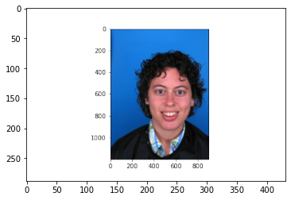

```python
plt.imshow(test_data[1])
```

#### 신경망 학습을 위한 데이터 전처리 및 신경망 구성

- 신경망에 적용하기 위해 배열 데이터를 numpy 타입으로 변환한다.

```python
test_data = np.array(test_data)
train_data = np.array(train_data)
```

```python
test_data.shape
```

```
(131, 288, 432, 4)
```

- 신경망에 적용하기 위해서는 각 이미지는 한 줄로 이루어져야 하므로, 이를 한줄로 펼치는 reshape 과정을 수행한다.

```python
test_data = test_data.reshape((131, 288, 432 * 4))
test_data = test_data.reshape((131, 288 * 432 * 4))

train_data = train_data.reshape((131, 288, 432 * 4))
train_data = train_data.reshape((131, 288 * 432 * 4))
```

- reshape한 데이터는 131개의 이미지가 한줄로 펼쳐졌다.

```python
train_data.shape
```

```
(131, 497664)
```

- 가중치의 개수를 확인하기 위해 하나의 층만을 갖는 신경망 모델을 설계한다.
- 입력층과 출력층의 노드의 수는 432 *288* 4인데, 이는 입력으로 모든 픽셀의 값을 받으며, 출력으로 눈, 코, 입부분이 빨간으로 표시된 이미지를 출력해야 하므로 이와 같이 설계한다.

```python
network = models.Sequential()
network.add(layers.Dense(432 * 288 * 4, activation='relu', input_shape=(432 * 288 * 4,)))
network.add(layers.Dense(432 * 288 * 4))
```

- 그러나 (432 *288* 4) *(432* 288 * 4)의 가중치 연결을 위해 매우 많은 연결이 필요하므로, 이는 개인 서버 환경에서는 학습이 불가능하다.

```python
network.summary()
```

```
_________________________________________________________________
Layer (type)                 Output Shape              Param #
=================================================================
dense_925 (Dense)            (None, 497664)            -143814860
_________________________________________________________________
dense_926 (Dense)            (None, 497664)            -143814860
=================================================================
Total params: 1,418,670,080
Trainable params: 1,418,670,080
Non-trainable params: 0
_________________________________________________________________
```

### 결론

- 인공 신경망을 통한 이미지 변환은 많은 연구가 진행되어 왔다.
- 이러한 점에서 인공 신경망을 통한 눈, 코, 입 탐지를 시도하려고 하였다.
- 입력으로 사용할 원본 이미지와, 출력으로 사용할 눈, 코, 입이 표시되어 있는 변환된 이미지를 인공신경망에 학습 시켜 눈, 코, 입을 표시하는 모델을 설계하였다.
- 눈, 코, 입 표시를 위해 기존에 제공되는 Harr Cascades와 MTCNN을 사용해보았다.
- MTCNN을 적용한 이미지를 데이터 세트로 저장하였다.
- 해당 데이터의 크기를 입력받고 출력하는 모델을 설계하였다.
- 매우 많은 가중치를 계산해야 하므로 개인 서버 환경에서는 학습이 불가능하였다.
- 순수한 인공 신경망을 통한 눈, 코, 입 식별은 완전 연결 모델 특성 상 학습하는 데에 매우 많은 시간이 걸릴 것으로 예측되어, 적절하지 못하다고 판단된다.
- 실제 모델을 사용하기 위해서는 전처리를 통하여 용량을 줄일 필요가 있으며, 적절한 필터링을 통해 눈, 코, 입을 추출하기 위한 특징 추출이 매우 중요해 보인다.